# hpgltools Differential Expression Analyses Using the Fission Dataset

atb abelew@gmail.com

2016-08-17

# Example hpgltool usage with a real data set (fission)

This document aims to provide further examples in how to use the hpgltools.

Note to self, the header has rmarkdown::pdf_document instead of html_document or html_vignette because it gets some bullcrap error ‘margins too large’…

## Setting up

Here are the commands I invoke to get ready to play with new data, including everything required to install hpgltools, the software it uses, and the fission data.

```r
## These first 4 lines are not needed once hpgltools is installed.
## source("http://bioconductor.org/biocLite.R")
## biocLite("devtools")
## library(devtools)
## install_github("elsayed-lab/hpgltools")
library(hpgltools)
require.auto("fission")
```

```
## [1] 0
```

```r
tt <- s_p(library(fission))
tt <- data(fission)
knitr::opts_knit$set(progress=TRUE, verbose=TRUE, error=TRUE,  fig.width=7, fig.height=7)
```

## Data import

All the work I do in Dr. El-Sayed’s lab makes some pretty hard assumptions about how data is stored. As a result, to use the fission data set I will do a little bit of shenanigans to match it to the expected format. Now that I have played a little with fission, I think its format is quite nice and am likely to have my experiment class instead be a SummarizedExperiment.

```r
## Extract the meta data from the fission dataset
meta <- as.data.frame(fission@colData)
## Make conditions and batches
meta$condition <- paste(meta$strain, meta$minute, sep=".")
meta$batch <- meta$replicate
meta$sample.id <- rownames(meta)
## Grab the count data
fission_data <- fission@assays$data$counts
## This will make an experiment superclass called 'expt' and it contains
## an ExpressionSet along with any arbitrary additional information one might want to include.
## Along the way it writes a Rdata file which is by default called 'expt.Rdata'
fission_expt <- create_expt(meta_dataframe=meta, count_dataframe=fission_data)
```

```
## Error in create_expt(meta_dataframe = meta, count_dataframe = fission_data): argument "metadata" is missing, with no default
```

# Some simple differential expression analyses

Travis wisely imposes a limit on the amount of time for building vignettes. My tools by default will attempt all possible pairwise comparisons, which takes a long time. Therefore I am going to take a subset of the data and limit these comparisons to that.

```r
fun_data <- expt_subset(fission_expt, subset="condition=='wt.120'|condition=='mut.120'")
fun_norm <- s_p(normalize_expt(fun_data, batch="limma", norm="quant", transform="log2", convert="cpm"))$result
```

```
## This function will replace the expt$expressionset slot with:
```

```
## log2(limma(cpm(quant(data))))
```

```
## It backs up the current data into a slot named:
##  expt$backup_expressionset. It will also save copies of each step along the way
##  in expt$normalized with the corresponding libsizes. Keep the libsizes in mind
##  when invoking limma.  The appropriate libsize is the non-log(cpm(normalized)).
##  This is most likely kept at:
##  'new_expt$normalized$intermediate_counts$normalization$libsizes'
##  A copy of this may also be found at:
##  new_expt$best_libsize
```

```
## Filter is false, this should likely be set to something, good
##  choices include cbcb, kofa, pofa (anything but FALSE).  If you want this to
##  stay FALSE, keep in mind that if other normalizations are performed, then the
##  resulting libsizes are likely to be strange (potentially negative!)
```

```
## Step 1: not doing count filtering.
```

```
## Step 2: normalizing the data with quant.
```

```
## Step 3: converting the data with cpm.
```

```
## Step 4: transforming the data with log2.
```

```
## transform_counts: Found 3715 values equal to 0, adding 1 to the matrix.
```

```
## Performing batch correction at step 5.
```

```
## Step 5: doing batch correction with limma.
```

```
## Note to self:  If you get an error like 'x contains missing values'; I think this means that the data has too many 0's and needs to have a better low-count filter applied.
```

```
## batch_counts: Before batch correction, 3939 entries 0<x<1.
```

```
## batch_counts: Before batch correction, 3715 entries are >= 0.
```

```
## batch_counts: Using limma's removeBatchEffect to remove batch effect.
```

```
## The number of elements which are < 0 after batch correction is: 376
```

```
## The variable low_to_zero sets whether to change <0 values to 0 and is: FALSE
```

## Try using limma first

```r
limma_comparison <- limma_pairwise(fun_norm)
```

```
## Starting limma pairwise comparison.
```

```
## libsize was not specified, this parameter has profound effects on limma's result.
```

```
## Using the libsize from expt$best_libsize.
```

```
## Choosing the intercept containing model.
```

```
## Limma step 1/6: choosing model.
```

```
## Limma step 2/6: running voom
```

```
## Limma step 3/6: running lmFit
```

```
## Limma step 4/6: making and fitting contrasts.
```

```
## Limma step 5/6: Running eBayes and topTable.
```

```
## Limma step 6/6: Writing limma outputs.
```

```
## Limma step 6/6: 1/3: Printing table: mut.120.
```

```
## Limma step 6/6: 2/3: Printing table: wt.120.
```

```
## Limma step 6/6: 3/3: Printing table: wt.120_vs_mut.120.
```

```r
names(limma_comparison$all_tables)
```

```
## [1] "mut.120"           "wt.120"            "wt.120_vs_mut.120"
```

```r
summary(limma_comparison$all_tables$wt.120_vs_mut.120)
```

```
##      logFC            AveExpr            t              P.Value
##  Min.   :-2.0700   Min.   : 0.00   Min.   :-14.160   Min.   :0.0011
##  1st Qu.:-0.0913   1st Qu.: 1.85   1st Qu.: -0.974   1st Qu.:0.1866
##  Median : 0.0000   Median : 4.30   Median :  0.000   Median :0.4389
##  Mean   :-0.0005   Mean   : 4.03   Mean   : -0.095   Mean   :0.4719
##  3rd Qu.: 0.0877   3rd Qu.: 5.73   3rd Qu.:  0.832   3rd Qu.:0.7466
##  Max.   : 1.6420   Max.   :18.35   Max.   : 13.080   Max.   :1.0000
##    adj.P.Val           B             qvalue
##  Min.   :0.600   Min.   :-5.79   Min.   :0.600
##  1st Qu.:0.744   1st Qu.:-5.31   1st Qu.:0.744
##  Median :0.877   Median :-5.07   Median :0.877
##  Mean   :0.855   Mean   :-4.81   Mean   :0.855
##  3rd Qu.:0.995   3rd Qu.:-4.43   3rd Qu.:0.995
##  Max.   :1.000   Max.   :-1.66   Max.   :1.000
```

```r
wt_120 <- limma_comparison$all_tables$wt.120
mut_120 <- limma_comparison$all_tables$mut.120
scatter_wt_mut <- limma_coefficient_scatter(limma_comparison, x="wt.120", y="mut.120", gvis_filename=NULL)
```

```
## This can do comparisons among the following columns in the limma result:
```

```
## mut.120, wt.120, wt.120_vs_mut.120
```

```
## Actually comparing wt.120 and mut.120.
```

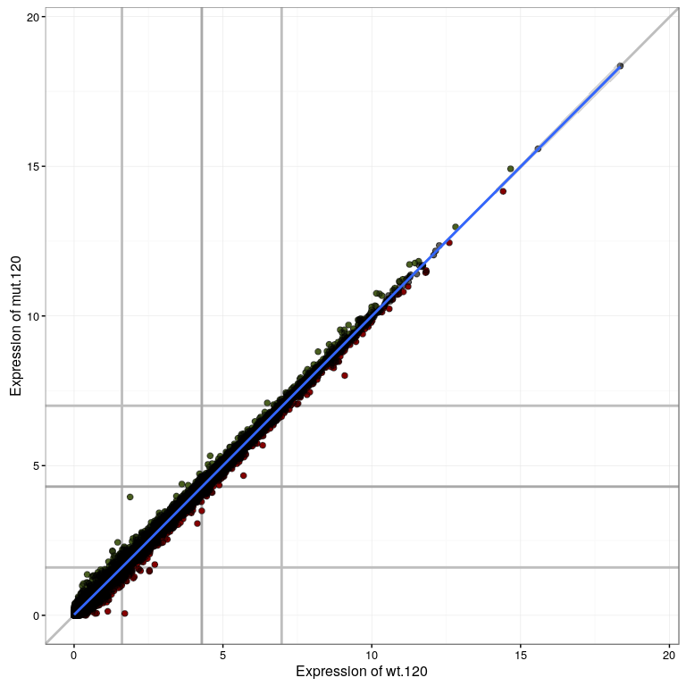

```r
scatter_wt_mut$scatter
```

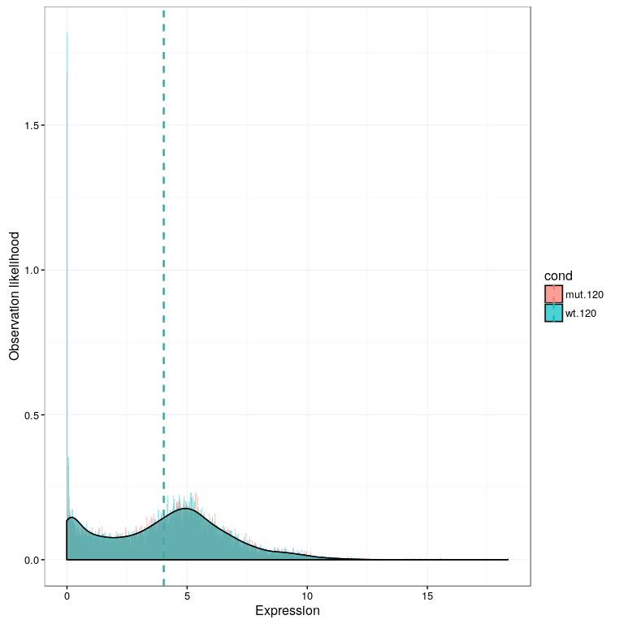

```
##
## $data_summary
##      wt.120          mut.120
##  Min.   :-0.007   Min.   :-0.007
##  1st Qu.: 1.843   1st Qu.: 1.843
##  Median : 4.292   Median : 4.297
##  Mean   : 4.027   Mean   : 4.028
##  3rd Qu.: 5.713   3rd Qu.: 5.733
##  Max.   :18.350   Max.   :18.350
##
## $uncor_t
##
##  Pairwise comparisons using t tests with pooled SD
##
## data:  play_all$expression and play_all$cond
##
##        mut.120
## wt.120 1
##
## P value adjustment method: none
##
## $bon_t
##
##  Pairwise comparisons using t tests with pooled SD
##
## data:  play_all$expression and play_all$cond
##
##        mut.120
## wt.120 1
##
## P value adjustment method: bonferroni
```

```r
scatter_wt_mut$both_histogram
```

## Then DESeq2

```r
deseq_comparison <- deseq2_pairwise(fun_data, model_batch=TRUE)
```

```
## Starting DESeq2 pairwise comparisons.
```

```
## The data should be suitable for EdgeR/DESeq.
```

```
## If EdgeR/DESeq freaks out, check the state of the count table and ensure that it is in integer counts.
```

```
## Choosing the intercept containing model.
```

```
## DESeq2 step 1/5: Including batch and condition in the deseq model.
```

```
## DESeq2 step 2/5: Estimate size factors.
```

```
## DESeq2 step 3/5: Estimate dispersions.
```

```
## DESeq2 step 4/5: nbinomWaldTest.
```

```
## DESeq2 step 5/5: 1/1: Printing table: wt.120_vs_mut.120
```

```
## Collected coefficients for: mut.120
```

```
## Collected coefficients for: wt.120
```

```r
summary(deseq_comparison$all_tables$wt.120_vs_mut.120)
```

```
##     baseMean           logFC          lfcSE          stat
##  Min.   :      0   Min.   :-0.4   Min.   :0.0   Min.   :-4.3
##  1st Qu.:     30   1st Qu.: 0.0   1st Qu.:0.1   1st Qu.:-0.5
##  Median :    215   Median : 0.0   Median :0.1   Median : 0.0
##  Mean   :   1645   Mean   : 0.0   Mean   :0.1   Mean   : 0.0
##  3rd Qu.:    597   3rd Qu.: 0.0   3rd Qu.:0.1   3rd Qu.: 0.5
##  Max.   :3976000   Max.   : 0.6   Max.   :0.1   Max.   : 4.7
##                    NA's   :387    NA's   :387   NA's   :387
##     P.Value        adj.P.Val          qvalue
##  Min.   :0.000   Min.   :0.0144   Min.   :0.0152
##  1st Qu.:0.409   1st Qu.:0.9997   1st Qu.:1.0000
##  Median :0.655   Median :0.9997   Median :1.0000
##  Mean   :0.619   Mean   :0.9982   Mean   :0.9986
##  3rd Qu.:0.859   3rd Qu.:0.9997   3rd Qu.:1.0000
##  Max.   :1.000   Max.   :1.0000   Max.   :1.0000
##
```

## And EdgeR

```r
edger_comparison <- s_p(edger_pairwise(fun_data, model_batch=TRUE))$result
```

```
## Starting edgeR pairwise comparisons.
```

```
## The data should be suitable for EdgeR/DESeq.
```

```
## If EdgeR/DESeq freaks out, check the state of the count table and ensure that it is in integer counts.
```

```
## Choosing the intercept containing model.
```

```
## EdgeR step 1/9: normalizing data.
```

```
## EdgeR step 9/9: 1/1: Printing table: wt.120_vs_mut.120.
```

```r
summary(edger_comparison$all_tables$wt.120_vs_mut.120)
```

```
##      logFC            logCPM            F             PValue
##  Min.   :-4.816   Min.   :-2.55   Min.   : 0.00   Min.   :0.000
##  1st Qu.:-0.120   1st Qu.: 1.49   1st Qu.: 0.08   1st Qu.:0.248
##  Median : 0.000   Median : 4.24   Median : 0.44   Median :0.517
##  Mean   :-0.028   Mean   : 3.60   Mean   : 1.19   Mean   :0.518
##  3rd Qu.: 0.102   3rd Qu.: 5.70   3rd Qu.: 1.45   3rd Qu.:0.787
##  Max.   : 5.263   Max.   :18.40   Max.   :54.12   Max.   :1.000
##       FDR           qvalue
##  Min.   :0.019   Length:7039
##  1st Qu.:0.991   Class :character
##  Median :1.000   Mode  :character
##  Mean   :0.984
##  3rd Qu.:1.000
##  Max.   :1.000
```

## My stupid basic comparison

```r
basic_comparison <- s_p(basic_pairwise(fun_data))$result
```

```
## Starting basic pairwise comparison.
```

```
## This basic pairwise function assumes log2, converted, normalized counts, normalizing now.
```

```
## Basic step 1/3: Creating median and variance tables.
```

```
## Basic step 2/3: Performing comparisons.
```

```
## Basic step 2/3: 1/1: Performing log2 subtraction: wt.120_vs_mut.120
```

```
## Basic step 3/3: Creating faux DE Tables.
```

```
## Basic: Returning tables.
```

```r
summary(basic_comparison$all_tables$wt.120_vs_mut.120)
```

```
##  numerator_median denominator_median numerator_var      denominator_var
##  Min.   :-4.54    Min.   :-4.54      Length:7039        Length:7039
##  1st Qu.: 1.39    1st Qu.: 1.41      Class :character   Class :character
##  Median : 4.24    Median : 4.22      Mode  :character   Mode  :character
##  Mean   : 3.34    Mean   : 3.35
##  3rd Qu.: 5.70    3rd Qu.: 5.70
##  Max.   :18.35    Max.   :18.35
##        t                p                 logFC            adjp
##  Min.   :-274800   Length:7039        Min.   :-3.793   Length:7039
##  1st Qu.:     -1   Class :character   1st Qu.:-0.115   Class :character
##  Median :      0   Mode  :character   Median : 0.000   Mode  :character
##  Mean   :    -16                      Mean   :-0.006
##  3rd Qu.:      1                      3rd Qu.: 0.112
##  Max.   : 158800                      Max.   : 4.967
```

## Combine them all

```r
all_comparisons <- s_p(all_pairwise(fun_data, model_batch=TRUE))$result
```

```
## Starting limma pairwise comparison.
```

```
## libsize was not specified, this parameter has profound effects on limma's result.
```

```
## Using the libsize from expt$libsize.
```

```
## Choosing the intercept containing model.
```

```
## Limma step 1/6: choosing model.
```

```
## Limma step 2/6: running voom
```

```
## The voom input was not cpm, converting now.
```

```
## The voom input was not log2, transforming now.
```

```
## Limma step 3/6: running lmFit
```

```
## Limma step 4/6: making and fitting contrasts.
```

```
## Limma step 5/6: Running eBayes and topTable.
```

```
## Limma step 6/6: Writing limma outputs.
```

```
## Limma step 6/6: 1/3: Printing table: mut.120.
```

```
## Limma step 6/6: 2/3: Printing table: wt.120.
```

```
## Limma step 6/6: 3/3: Printing table: wt.120_vs_mut.120.
```

```
## Starting DESeq2 pairwise comparisons.
```

```
## The data should be suitable for EdgeR/DESeq.
```

```
## If EdgeR/DESeq freaks out, check the state of the count table and ensure that it is in integer counts.
```

```
## Choosing the intercept containing model.
```

```
## DESeq2 step 1/5: Including batch and condition in the deseq model.
```

```
## DESeq2 step 2/5: Estimate size factors.
```

```
## DESeq2 step 3/5: Estimate dispersions.
```

```
## DESeq2 step 4/5: nbinomWaldTest.
```

```
## DESeq2 step 5/5: 1/1: Printing table: wt.120_vs_mut.120
```

```
## Collected coefficients for: mut.120
```

```
## Collected coefficients for: wt.120
```

```
## Starting edgeR pairwise comparisons.
```

```
## The data should be suitable for EdgeR/DESeq.
```

```
## If EdgeR/DESeq freaks out, check the state of the count table and ensure that it is in integer counts.
```

```
## Choosing the intercept containing model.
```

```
## EdgeR step 1/9: normalizing data.
```

```
## EdgeR step 9/9: 1/1: Printing table: wt.120_vs_mut.120.
```

```
## Starting basic pairwise comparison.
```

```
## This basic pairwise function assumes log2, converted, normalized counts, normalizing now.
```

```
## Basic step 1/3: Creating median and variance tables.
```

```
## Basic step 2/3: Performing comparisons.
```

```
## Basic step 2/3: 1/1: Performing log2 subtraction: wt.120_vs_mut.120
```

```
## Basic step 3/3: Creating faux DE Tables.
```

```
## Basic: Returning tables.
```

```
## Comparing analyses 1/1: wt.120_vs_mut.120
```

```r
all_combined <- combine_de_tables(all_comparisons)
```

```
## Writing a legend of columns.
```

```
## Working on table 1/1: wt.120_vs_mut.120
```

```
## The table is: wt.120_vs_mut.120
```

```r
sig_genes <- extract_significant_genes(all_combined, excel=NULL)
```

```
## Writing excel data sheet 1/6
```

```
## Assuming the fold changes are on the log scale and so taking >< 0
```

```
## After (adj)p filter, the up genes table has 7 genes.
```

```
## After (adj)p filter, the down genes table has 8 genes.
```

```
## Assuming the fold changes are on the log scale and so taking -1 * fc
```

```
## After fold change filter, the up genes table has 7 genes.
```

```
## After fold change filter, the down genes table has 8 genes.
```

```
## Not printing excel sheets for the significant genes.
```

```
## Writing excel data sheet 2/6
```

```
## Assuming the fold changes are on the log scale and so taking >< 0
```

```
## After (adj)p filter, the up genes table has 2 genes.
```

```
## After (adj)p filter, the down genes table has 0 genes.
```

```
## Assuming the fold changes are on the log scale and so taking -1 * fc
```

```
## After fold change filter, the up genes table has 2 genes.
```

```
## After fold change filter, the down genes table has 0 genes.
```

```
## Not printing excel sheets for the significant genes.
```

```
## Writing excel data sheet 3/6
```

```
## Assuming the fold changes are on the log scale and so taking >< 0
```

```
## After (adj)p filter, the up genes table has 2 genes.
```

```
## After (adj)p filter, the down genes table has 1 genes.
```

```
## Assuming the fold changes are on the log scale and so taking -1 * fc
```

```
## After fold change filter, the up genes table has 0 genes.
```

```
## After fold change filter, the down genes table has 0 genes.
```

```
## Not printing excel sheets for the significant genes.
```

```
## Writing excel data sheet 4/6
```

```
## Assuming the fold changes are on the log scale and so taking >< 0
```

```
## After (adj)p filter, the up genes table has 1 genes.
```

```
## After (adj)p filter, the down genes table has 1 genes.
```

```
## Assuming the fold changes are on the log scale and so taking -1 * fc
```

```
## After fold change filter, the up genes table has 1 genes.
```

```
## After fold change filter, the down genes table has 1 genes.
```

```
## Not printing excel sheets for the significant genes.
```

## Ontology searches

The following works, but on travis to causes the vignette build time to exceed the maximum allowed, which is weird because on my computer it only takes like 4 minutes.

### Setting up

Since I didn’t acquire this data in a ‘normal’ way, I am going to post-generate a gff file which may be used by clusterprofiler, topgo, and gostats.

Therefore, I am going to make use of TxDb to make the requisite gff file.

```r
limma_results <- limma_comparison$all_tables
## The set of comparisons performed
names(limma_results)
```

```
## [1] "mut.120"           "wt.120"            "wt.120_vs_mut.120"
```

```r
table <- limma_results$wt.120_vs_mut.120
dim(table)
```

```
## [1] 7039    7
```

```r
gene_names <- rownames(table)

updown_genes <- get_sig_genes(table, p=0.1, fc=0.8, p_column="P.Value")
```

```
## Assuming the fold changes are on the log scale and so taking >< 0
```

```
## After (adj)p filter, the up genes table has 435 genes.
```

```
## After (adj)p filter, the down genes table has 567 genes.
```

```
## Assuming the fold changes are on the log scale and so taking -1 * fc
```

```
## After fold change filter, the up genes table has 5 genes.
```

```
## After fold change filter, the down genes table has 5 genes.
```

```r
require.auto("GenomicFeatures")
```

```
## [1] 0
```

```r
require.auto("biomaRt")
```

```
## [1] 0
```

```r
ensembl_pombe <- biomaRt::useMart("fungal_mart", dataset="spombe_eg_gene", host="fungi.ensembl.org")
pombe_filters <- biomaRt::listFilters(ensembl_pombe)
head(pombe_filters, n=20) ## 11 looks to be my guy
```

```
##                     name                             description
## 1        chromosome_name                         Chromosome name
## 2                  start                                   Start
## 3                    end                                     End
## 4                 strand                                  Strand
## 5     chromosomal_region e.g. 1:100:10000:-1, 1:100000:2000000:1
## 6            with_chembl                       with ChEMBL ID(s)
## 7              with_embl                  with ENA/GenBank ID(s)
## 8        with_protein_id          with ENA/GenBank protein ID(s)
## 9        with_entrezgene                   with EntrezGene ID(s)
## 10             with_fypo             with FYPO term accession(s)
## 11      with_ontology_go                           with GO ID(s)
## 12               with_go               with GO term accession(s)
## 13    with_ox_goslim_goa                   with GOSlim GOA ID(s)
## 14      with_kegg_enzyme                  with KEGG enzyme ID(s)
## 15           with_merops                       with MEROPS ID(s)
## 16          with_metacyc                      with Metacyc ID(s)
## 17              with_mod              with MOD term accession(s)
## 18              with_pdb                          with PDB ID(s)
## 19              with_pbo with PomBase Ontology term accession(s)
## 20 with_pombase_ortholog             with PomBase ortholog ID(s)
```

```r
possible_pombe_attributes <- biomaRt::listAttributes(ensembl_pombe)
##pombe_goids <- biomaRt::getBM(attributes=c('pombase_gene_name', 'go_accession'), filters="biotype", values=gene_names, mart=ensembl_pombe)
pombe_goids <- biomaRt::getBM(attributes=c('pombase_transcript', 'go_accession'), values=gene_names, mart=ensembl_pombe)
colnames(pombe_goids) <- c("ID","GO")

pombe <- GenomicFeatures::makeTxDbFromBiomart(biomart ="fungal_mart", dataset = "spombe_eg_gene", host="fungi.ensembl.org")
```

```
## Download and preprocess the 'transcripts' data frame ...
```

```
## OK
```

```
## Download and preprocess the 'splicings' data frame ...
```

```
## OK
```

```
## Download and preprocess the 'genes' data frame ...
```

```
## OK
```

```
## Prepare the 'metadata' data frame ...
```

```
## OK
```

```
## Make the TxDb object ...
```

```
## OK
```

```r
pombe_transcripts <- as.data.frame(GenomicFeatures::transcriptsBy(pombe))
lengths <- pombe_transcripts[, c("group_name","width")]
colnames(lengths) <- c("ID","width")
## Something useful I didn't notice before:
## makeTranscriptDbFromGFF()  ## From GenomicFeatures, much like my own gff2df()
gff_from_txdb <- GenomicFeatures::asGFF(pombe)
## why is GeneID: getting prefixed to the IDs!?
gff_from_txdb$ID <- gsub(x=gff_from_txdb$ID, pattern="GeneID:", replacement="")
written_gff <- rtracklayer::export.gff3(gff_from_txdb, con="pombe.gff")
```